# Data Viz Part II

N.Paterno

## Custom Data Visualization

For this lab, we will once again be adjusting the histogram we made in lab 1. Instead of using a prebuilt theme from the *ggthemes* package, we will be creating our own unique visualizations.

First, lets start with our plot from lab 3 that included labels.

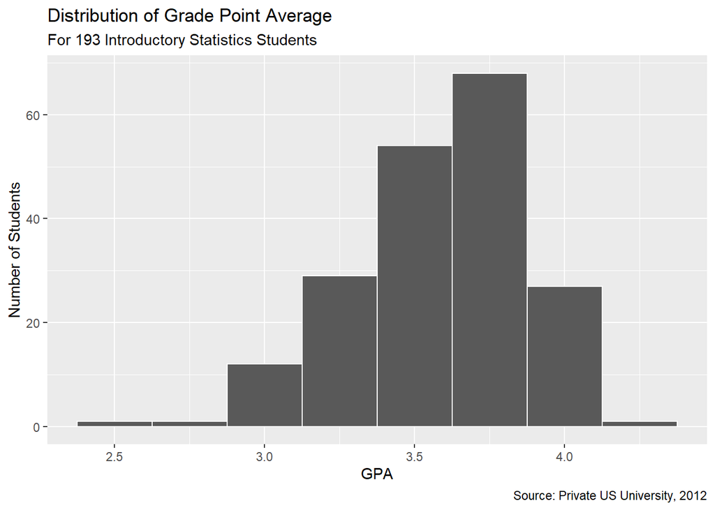

```r
ggplot(data = gpa_study_hours,
       aes(x = gpa))+
  geom_histogram(color = "White", binwidth = 0.25)+
  labs( #the labs() function allows us to add labels to our graph
    title = "Distribution of Grade Point Average",
    subtitle = "For 193 Introductory Statistics Students",
    x = "GPA",
    y = "Number of Students",
    caption = "Source: Private US University, 2012"
  )
```

To customize a ggplot image, we’ll add a *theme()* function to the end and change specific parts of the graph. Here is a [full list](https://ggplot2.tidyverse.org/reference/theme.html) of what you can change with the theme() function. It is a substantial list but don’t worry, we won’t change all of them.

First I’m going to adjust my *text*. I’d prefer to have my title a little larger and in Times New Roman font (which R maps to serif). I’d also like the axis labels to be in italics.

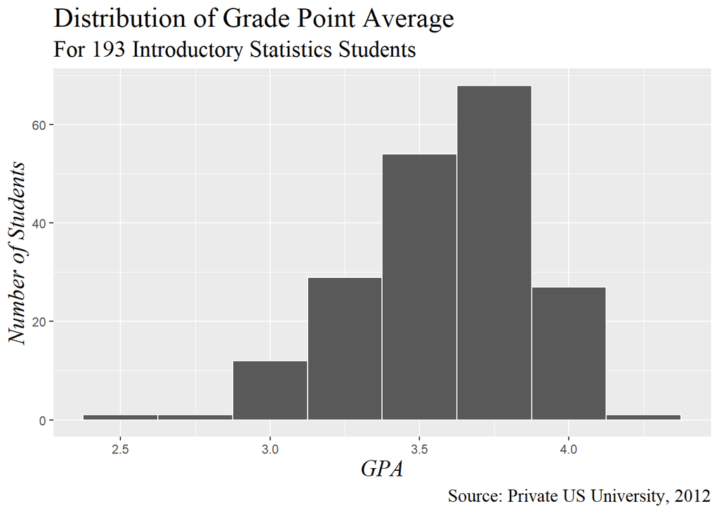

```r
ggplot(data = gpa_study_hours,
       aes(x = gpa))+
  geom_histogram(color = "White", binwidth = 0.25)+
  labs( #the labs() function allows us to add labels to our graph
    title = "Distribution of Grade Point Average",
    subtitle = "For 193 Introductory Statistics Students",
    x = "GPA",
    y = "Number of Students",
    caption = "Source: Private US University, 2012"
  )+
  theme(
    title = element_text(size = 16,
                              family = "serif"),
    axis.title = element_text(face = "italic")
  )
```

Next, I’m going to adjust the *panel* the plot is on. I’ll change the background and grid colors.

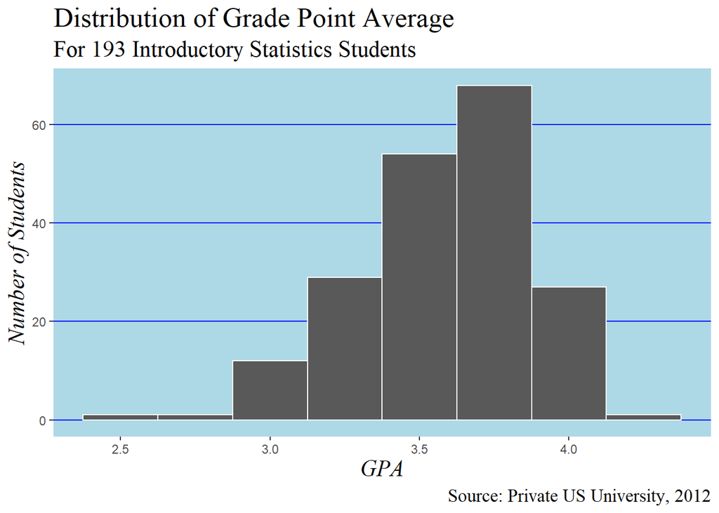

```r
ggplot(data = gpa_study_hours,
       aes(x = gpa))+
  geom_histogram(color = "White", binwidth = 0.25)+
  labs( #the labs() function allows us to add labels to our graph
    title = "Distribution of Grade Point Average",
    subtitle = "For 193 Introductory Statistics Students",
    x = "GPA",
    y = "Number of Students",
    caption = "Source: Private US University, 2012"
  )+
  theme(
    title = element_text(size = 16, #element_text changes any traits of the text
                              family = "serif"),
    axis.title = element_text(face = "italic"),
    panel.background = element_rect(fill = "lightblue"), #element_rect lets us change geometric traits of the panel or plot.
    panel.grid.major.x = element_blank(), #element_blank will "erase" a feature
    panel.grid.minor.x = element_blank(),
    panel.grid.major.y = element_line(color = "blue"), #element_line changes any (you guessed it) line traits
    panel.grid.minor.y = element_blank()
  )
```

My next step will be to address the *plot* background (the white space behind the blue). I’d like it to be the same color. I’ll also adjust the color and fill of the bars.

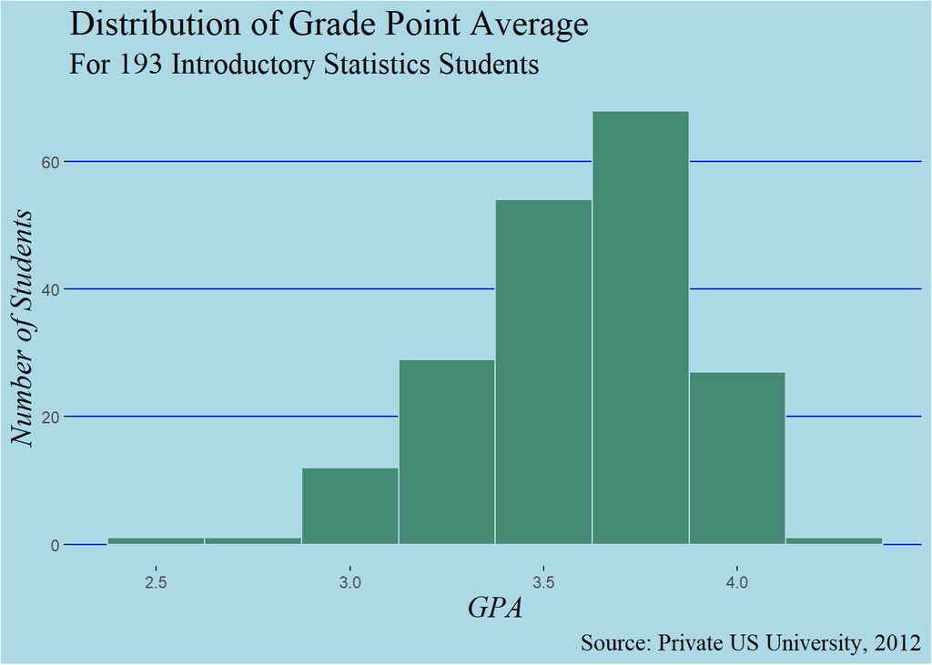

```r
ggplot(data = gpa_study_hours,
       aes(x = gpa))+
  geom_histogram(fill = "aquamarine4",
                 color = "lightblue",
                 binwidth = 0.25)+
  labs( #the labs() function allows us to add labels to our graph
    title = "Distribution of Grade Point Average",
    subtitle = "For 193 Introductory Statistics Students",
    x = "GPA",
    y = "Number of Students",
    caption = "Source: Private US University, 2012"
  )+
  theme(
    title = element_text(size = 16, #element_text changes any traits of the text
                              family = "serif"),
    axis.title = element_text(face = "italic"),
    panel.background = element_rect(fill = "lightblue"), #element_rect lets us change geometric traits of the panel or plot.
    panel.grid.major.x = element_blank(), #element_blank will "erase" a feature
    panel.grid.minor.x = element_blank(),
    panel.grid.major.y = element_line(color = "blue"), #element_line changes any (you guessed it) line traits
    panel.grid.minor.y = element_blank(),
    plot.background = element_rect(fill = "lightblue")
  )
```